# Регрессия

Ораз Динислам

## Регрессионный анализ

Является основой всех основ как статистики, так и машинного обучения. То есть регрессионным анализом можно сравнивать взаимосвязь двух или более групп переменных, а так же делать прогноз на основе независимых переменных.

### Основные ограничения регрессии

Давайте для более легкого понимания мы будем рассматривать лишь две перменные, одна НП, одна ЗП и они оба количественные .

- Линейность связи ЗП и НП.
- Независимость наблюдений
- Независимость предикторов
- Гомоскедастичность
- Нормальное распределение остатков
- Отсутствие автокорреляции остатков

### Линейность взаимосвязи

Допустим мы хотим проверить линейность взаимосвязи двух переменных. На графие мы может видеть hp на mpg с данных mtcars.

### `mpg=b0+b1*hp` уравнением это можно написать таким образом

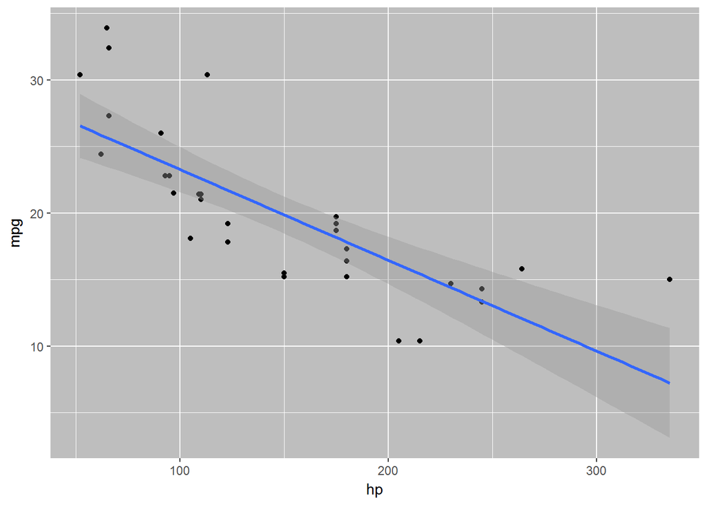

```r
library(ggplot2)
qplot(x=hp,y=mpg,data=mtcars)+ geom_smooth(method = 'lm') + theme(panel.background = element_rect(fill = 'gray'))
```

На самом графике видно, что взаимосвязь между **лошадинными силами** и **расходом топлива** является не совсем линейным

#### Как можно спасти ситуацию?

Можно трансформировать НП или ЗП или же оба

#### Трансформация Тьюки

** Основная идея** трансформировать НП, чтобы ликвидировать нелинейность свзяи. Метод трансформации - возведение в степень НП.

- елси **y>0** `x^y`
- если **y=0** `logx`
- если **y<0** `-(x^y)`

Для некоторых значений показателя степени требуется, чтобы значения переменной были неотрицательными. При использовании отрицательного показателя степени мы берем получившуюся переменную с обратным знаком, чтобы избежать изменения направления исходной взаимосвязи. Если бы мы использовали ноль в качестве показателя степени, то все значения переменной стали бы равны друг другу.

#### **Давайте попробуем сами сделать трансформацию Тьюки на тех же переменных**

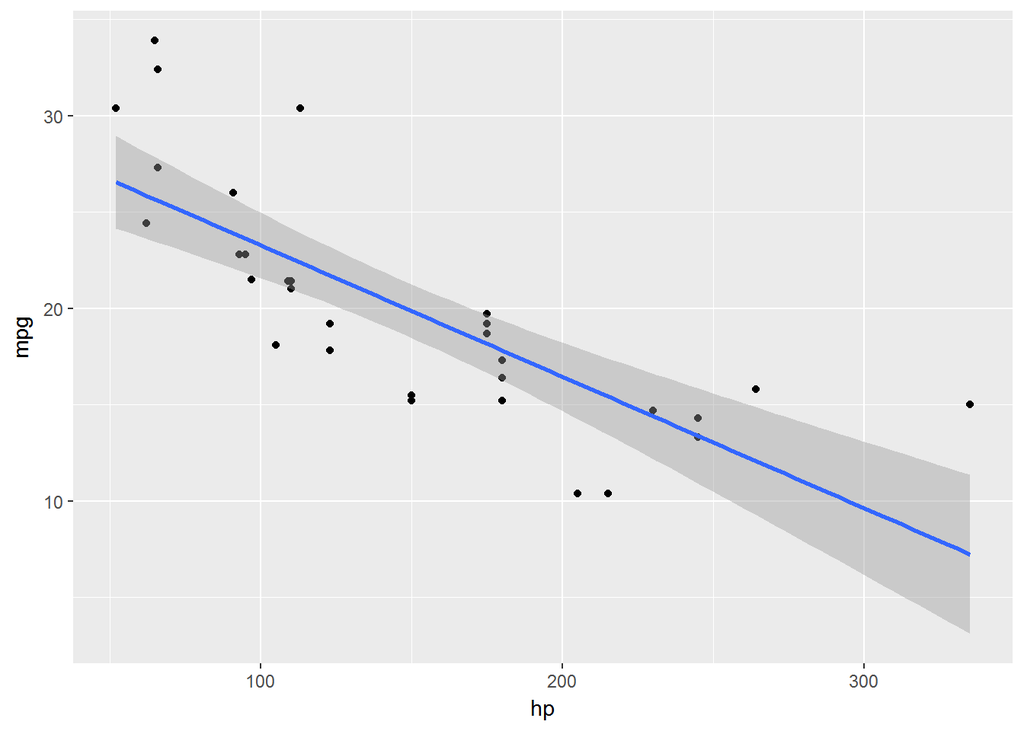

```r
qplot(x=hp,y=mpg,data=mtcars)+ geom_smooth(method = 'lm')
```

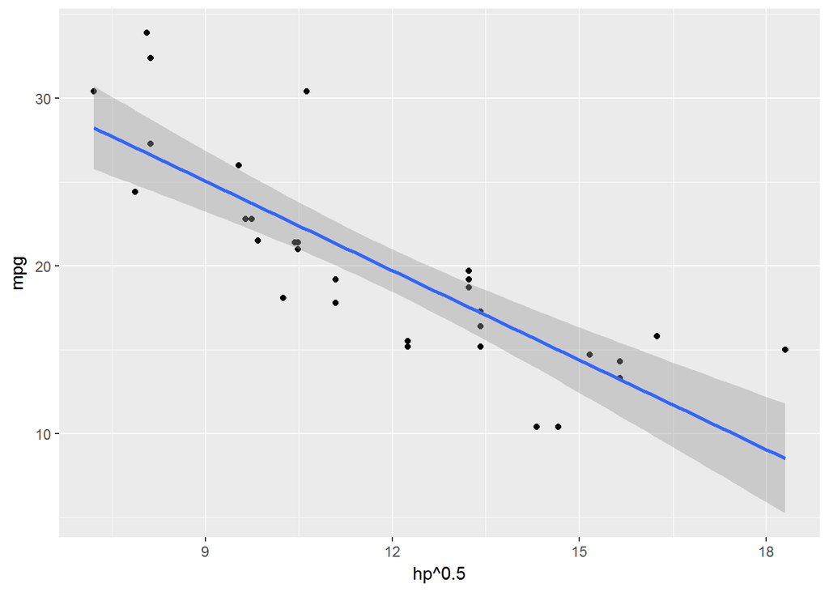

```r
qplot(x=hp^0.5,y=mpg,data=mtcars)+ geom_smooth(method = 'lm')
```

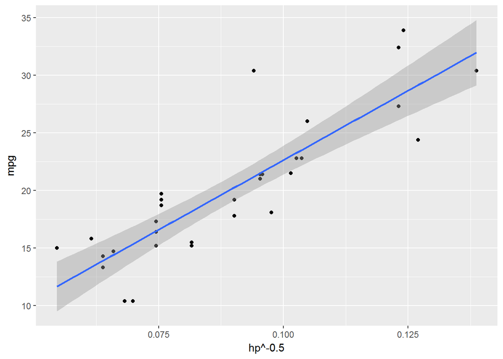

```r
qplot(x=hp^-0.5,y=mpg,data=mtcars)+ geom_smooth(method = 'lm')
```

```r
cor.test(mtcars$mpg,mtcars$hp)
```

```
##
##  Pearson's product-moment correlation
##
## data:  mtcars$mpg and mtcars$hp
## t = -6.7424, df = 30, p-value = 1.788e-07
## alternative hypothesis: true correlation is not equal to 0
## 95 percent confidence interval:
##  -0.8852686 -0.5860994
## sample estimates:
##        cor
## -0.7761684
```

```r
cor.test(mtcars$mpg,mtcars$hp^0.5)
```

```
##
##  Pearson's product-moment correlation
##
## data:  mtcars$mpg and mtcars$hp^0.5
## t = -7.8282, df = 30, p-value = 9.796e-09
## alternative hypothesis: true correlation is not equal to 0
## 95 percent confidence interval:
##  -0.9084895 -0.6589155
## sample estimates:
##        cor
## -0.8193547
```

#### Знакомство с логарифмической трансформацией переменных

Наша цель заключается в том, чтобы найти такую трансформацию чтобы найти самую лучшую взаимосвзяь переменных

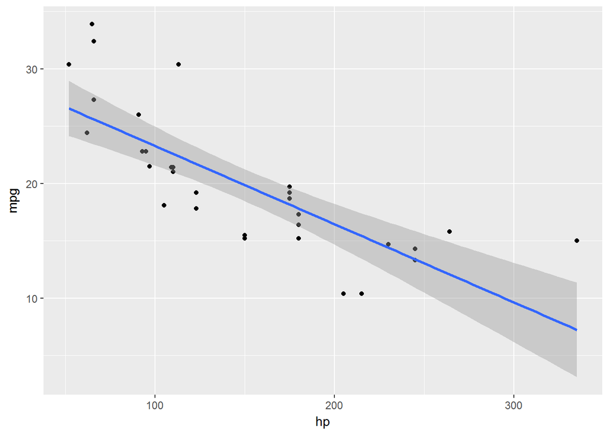

```r
qplot(x=hp,y=mpg,data=mtcars)+ geom_smooth(method = 'lm')
```

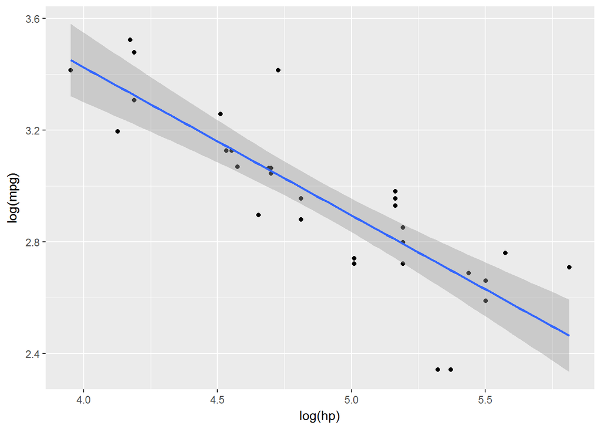

```r
qplot(x=log(hp),y=log(mpg),data=mtcars)+ geom_smooth(method = 'lm')
```